# Risk Factor Analysis

## Outcome Variable

**Outcome Variable:** stunted

## Predictor Variables

**Intervention Variable:** nchldlt5

**Adjustment Set:**

unadjusted

## Stratifying Variables

The analysis was stratified on these variable(s):

- agecat
- studyid

The following strata were considered:

- agecat: 12 months, studyid: ki1000108-IRC
- agecat: 12 months, studyid: ki1017093b-PROVIDE
- agecat: 12 months, studyid: ki1017093c-NIH-Crypto
- agecat: 12 months, studyid: ki1066203-TanzaniaChild2
- agecat: 12 months, studyid: ki1148112-LCNI-5
- agecat: 18 months, studyid: ki1000108-IRC
- agecat: 18 months, studyid: ki1017093b-PROVIDE
- agecat: 18 months, studyid: ki1017093c-NIH-Crypto
- agecat: 18 months, studyid: ki1066203-TanzaniaChild2
- agecat: 18 months, studyid: ki1148112-LCNI-5
- agecat: 24 months, studyid: ki1000108-IRC
- agecat: 24 months, studyid: ki1017093b-PROVIDE
- agecat: 24 months, studyid: ki1017093c-NIH-Crypto
- agecat: 24 months, studyid: ki1066203-TanzaniaChild2
- agecat: 24 months, studyid: ki1148112-LCNI-5
- agecat: 3 months, studyid: ki1000108-IRC
- agecat: 3 months, studyid: ki1017093b-PROVIDE
- agecat: 3 months, studyid: ki1017093c-NIH-Crypto
- agecat: 3 months, studyid: ki1066203-TanzaniaChild2
- agecat: 6 months, studyid: ki1000108-IRC
- agecat: 6 months, studyid: ki1017093b-PROVIDE
- agecat: 6 months, studyid: ki1017093c-NIH-Crypto
- agecat: 6 months, studyid: ki1066203-TanzaniaChild2
- agecat: 6 months, studyid: ki1148112-LCNI-5
- agecat: 9 months, studyid: ki1000108-IRC
- agecat: 9 months, studyid: ki1017093b-PROVIDE
- agecat: 9 months, studyid: ki1017093c-NIH-Crypto
- agecat: 9 months, studyid: ki1066203-TanzaniaChild2
- agecat: 9 months, studyid: ki1148112-LCNI-5
- agecat: Birth, studyid: ki1000108-IRC
- agecat: Birth, studyid: ki1017093c-NIH-Crypto

### Dropped Strata

Some strata were dropped due to rare outcomes:

- agecat: Birth, studyid: ki1017093c-NIH-Crypto
- agecat: 3 months, studyid: ki1017093b-PROVIDE
- agecat: 3 months, studyid: ki1017093c-NIH-Crypto
- agecat: 3 months, studyid: ki1066203-TanzaniaChild2
- agecat: 6 months, studyid: ki1017093b-PROVIDE
- agecat: 6 months, studyid: ki1017093c-NIH-Crypto
- agecat: 6 months, studyid: ki1066203-TanzaniaChild2
- agecat: 6 months, studyid: ki1148112-LCNI-5
- agecat: 9 months, studyid: ki1017093b-PROVIDE
- agecat: 9 months, studyid: ki1017093c-NIH-Crypto
- agecat: 9 months, studyid: ki1066203-TanzaniaChild2
- agecat: 9 months, studyid: ki1148112-LCNI-5
- agecat: 12 months, studyid: ki1017093b-PROVIDE
- agecat: 12 months, studyid: ki1017093c-NIH-Crypto
- agecat: 12 months, studyid: ki1066203-TanzaniaChild2
- agecat: 12 months, studyid: ki1148112-LCNI-5
- agecat: 18 months, studyid: ki1017093b-PROVIDE
- agecat: 18 months, studyid: ki1017093c-NIH-Crypto
- agecat: 18 months, studyid: ki1066203-TanzaniaChild2
- agecat: 18 months, studyid: ki1148112-LCNI-5
- agecat: 24 months, studyid: ki1017093b-PROVIDE
- agecat: 24 months, studyid: ki1017093c-NIH-Crypto
- agecat: 24 months, studyid: ki1066203-TanzaniaChild2
- agecat: 24 months, studyid: ki1148112-LCNI-5

## Methods Detail

We’re interested in the causal parameters $E[Y_a]$ for all values of $a \in \mathcal{A}$. These parameters represent the mean outcome if, possibly contrary to fact, we intervened to set all units to have $A=a$. Under the randomization and positivity assumptions, these are identified by the statistical parameters $\psi_a=E_W[E_{Y|A,W}(Y|A=a,W)]$. In addition, we’re interested in the mean of $Y$, $E[Y]$ under no intervention (the observed mean). We will estimate these parameters by using SuperLearner to fit the relevant likelihood factors – $E_{Y|A,W}(Y|A=a,W)$ and $p(A=a|W)$, and then updating our likelihood fit using a joint TMLE.

For unadjusted analyses ($W=\{\}$), initial likelihoods were estimated using Lrnr_glm to estimate the simple $E(Y|A)$ and Lrnr_mean to estimate $p(A)$. For adjusted analyses, a small library containing Lrnr_glmnet, Lrnr_xgboost, and Lrnr_mean was used.

Having estimated these parameters, we will then use the delta method to estimate relative risks and attributable risks relative to a prespecified baseline level of $A$.

# Results Detail

## Results Plots

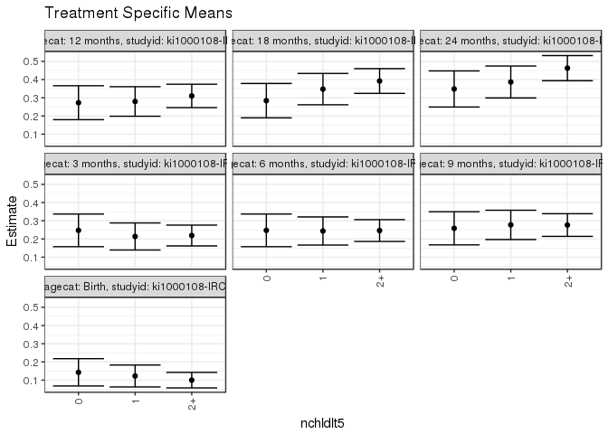

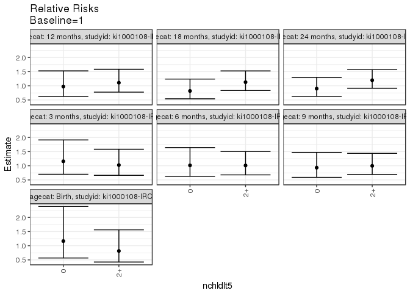

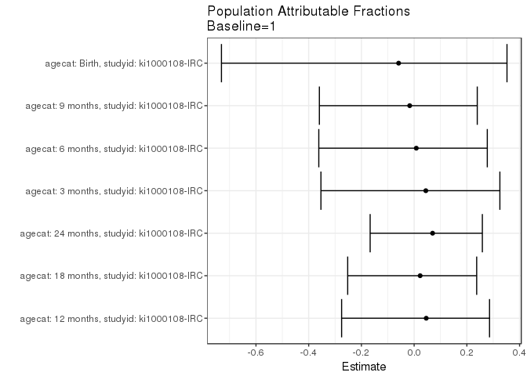

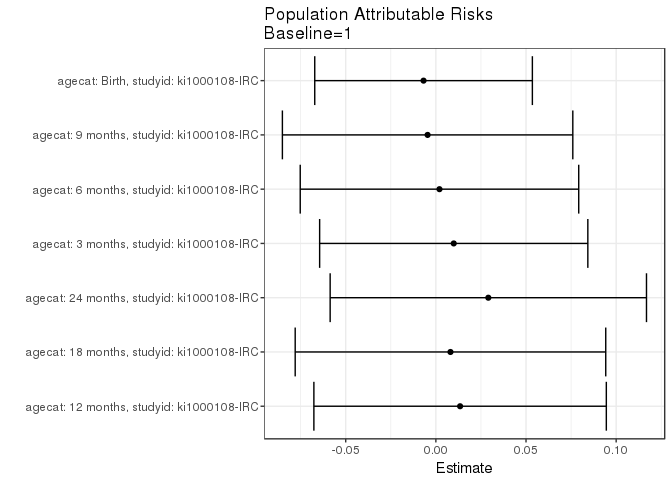

## Data Summary

| agecat | studyid | A | n | nA | nAY0 | nAY1 |
| --- | --- | --- | --- | --- | --- | --- |
| Birth | ki1000108-IRC | 1 | 388 | 114 | 100 | 14 |
| Birth | ki1000108-IRC | 0 | 388 | 84 | 72 | 12 |
| Birth | ki1000108-IRC | 2+ | 388 | 190 | 171 | 19 |
| Birth | ki1017093b-PROVIDE | 1 | 0 | 0 | 0 | 0 |
| Birth | ki1017093b-PROVIDE | 0 | 0 | 0 | 0 | 0 |
| Birth | ki1017093b-PROVIDE | 2+ | 0 | 0 | 0 | 0 |
| Birth | ki1017093c-NIH-Crypto | 1 | 27 | 8 | 7 | 1 |
| Birth | ki1017093c-NIH-Crypto | 0 | 27 | 18 | 14 | 4 |
| Birth | ki1017093c-NIH-Crypto | 2+ | 27 | 1 | 1 | 0 |
| Birth | ki1066203-TanzaniaChild2 | 1 | 0 | 0 | 0 | 0 |
| Birth | ki1066203-TanzaniaChild2 | 0 | 0 | 0 | 0 | 0 |
| Birth | ki1066203-TanzaniaChild2 | 2+ | 0 | 0 | 0 | 0 |
| Birth | ki1148112-LCNI-5 | 1 | 0 | 0 | 0 | 0 |
| Birth | ki1148112-LCNI-5 | 0 | 0 | 0 | 0 | 0 |
| Birth | ki1148112-LCNI-5 | 2+ | 0 | 0 | 0 | 0 |
| 3 months | ki1000108-IRC | 1 | 407 | 117 | 92 | 25 |
| 3 months | ki1000108-IRC | 0 | 407 | 89 | 67 | 22 |
| 3 months | ki1000108-IRC | 2+ | 407 | 201 | 157 | 44 |
| 3 months | ki1017093b-PROVIDE | 1 | 168 | 45 | 41 | 4 |
| 3 months | ki1017093b-PROVIDE | 0 | 168 | 120 | 104 | 16 |
| 3 months | ki1017093b-PROVIDE | 2+ | 168 | 3 | 3 | 0 |
| 3 months | ki1017093c-NIH-Crypto | 1 | 728 | 204 | 153 | 51 |
| 3 months | ki1017093c-NIH-Crypto | 0 | 728 | 518 | 413 | 105 |
| 3 months | ki1017093c-NIH-Crypto | 2+ | 728 | 6 | 6 | 0 |
| 3 months | ki1066203-TanzaniaChild2 | 1 | 574 | 157 | 146 | 11 |
| 3 months | ki1066203-TanzaniaChild2 | 0 | 574 | 397 | 370 | 27 |
| 3 months | ki1066203-TanzaniaChild2 | 2+ | 574 | 20 | 19 | 1 |
| 3 months | ki1148112-LCNI-5 | 1 | 0 | 0 | 0 | 0 |
| 3 months | ki1148112-LCNI-5 | 0 | 0 | 0 | 0 | 0 |
| 3 months | ki1148112-LCNI-5 | 2+ | 0 | 0 | 0 | 0 |

[output cut: 75 more lines]

## Results Table

### Parameter: TSM

| agecat | studyid | intervention_level | baseline_level | estimate | ci_lower | ci_upper |
| --- | --- | --- | --- | --- | --- | --- |
| Birth | ki1000108-IRC | 1 | NA | 0.1228070 | 0.0624795 | 0.1831345 |
| Birth | ki1000108-IRC | 0 | NA | 0.1428571 | 0.0679288 | 0.2177855 |
| Birth | ki1000108-IRC | 2+ | NA | 0.1000000 | 0.0572877 | 0.1427123 |
| 3 months | ki1000108-IRC | 1 | NA | 0.2136752 | 0.1393104 | 0.2880400 |
| 3 months | ki1000108-IRC | 0 | NA | 0.2471910 | 0.1574593 | 0.3369227 |
| 3 months | ki1000108-IRC | 2+ | NA | 0.2189055 | 0.1616701 | 0.2761408 |
| 6 months | ki1000108-IRC | 1 | NA | 0.2436975 | 0.1664682 | 0.3209268 |
| 6 months | ki1000108-IRC | 0 | NA | 0.2471910 | 0.1574593 | 0.3369227 |
| 6 months | ki1000108-IRC | 2+ | NA | 0.2462312 | 0.1863009 | 0.3061614 |
| 9 months | ki1000108-IRC | 1 | NA | 0.2773109 | 0.1967790 | 0.3578428 |
| 9 months | ki1000108-IRC | 0 | NA | 0.2584270 | 0.1673658 | 0.3494881 |
| 9 months | ki1000108-IRC | 2+ | NA | 0.2763819 | 0.2141712 | 0.3385926 |
| 12 months | ki1000108-IRC | 1 | NA | 0.2796610 | 0.1985785 | 0.3607435 |
| 12 months | ki1000108-IRC | 0 | NA | 0.2727273 | 0.1795618 | 0.3658928 |
| 12 months | ki1000108-IRC | 2+ | NA | 0.3100000 | 0.2458238 | 0.3741762 |
| 18 months | ki1000108-IRC | 1 | NA | 0.3474576 | 0.2614377 | 0.4334776 |
| 18 months | ki1000108-IRC | 0 | NA | 0.2840909 | 0.1897498 | 0.3784321 |
| 18 months | ki1000108-IRC | 2+ | NA | 0.3919598 | 0.3240480 | 0.4598716 |
| 24 months | ki1000108-IRC | 1 | NA | 0.3865546 | 0.2989555 | 0.4741537 |
| 24 months | ki1000108-IRC | 0 | NA | 0.3483146 | 0.2492110 | 0.4474182 |
| 24 months | ki1000108-IRC | 2+ | NA | 0.4626866 | 0.3936723 | 0.5317008 |

### Parameter: E(Y)

| agecat | studyid | intervention_level | baseline_level | estimate | ci_lower | ci_upper |
| --- | --- | --- | --- | --- | --- | --- |
| Birth | ki1000108-IRC | NA | NA | 0.1159794 | 0.1142678 | 0.1176910 |
| 3 months | ki1000108-IRC | NA | NA | 0.2235872 | 0.2223534 | 0.2248211 |
| 6 months | ki1000108-IRC | NA | NA | 0.2457002 | 0.2455699 | 0.2458306 |
| 9 months | ki1000108-IRC | NA | NA | 0.2727273 | 0.2719904 | 0.2734642 |
| 12 months | ki1000108-IRC | NA | NA | 0.2931034 | 0.2914646 | 0.2947423 |
| 18 months | ki1000108-IRC | NA | NA | 0.3555556 | 0.3514415 | 0.3596696 |
| 24 months | ki1000108-IRC | NA | NA | 0.4156479 | 0.4109740 | 0.4203219 |

### Parameter: RR

| agecat | studyid | intervention_level | baseline_level | estimate | ci_lower | ci_upper |
| --- | --- | --- | --- | --- | --- | --- |
| Birth | ki1000108-IRC | 0 | 1 | 1.1632653 | 0.5670043 | 2.386554 |
| Birth | ki1000108-IRC | 2+ | 1 | 0.8142857 | 0.4246865 | 1.561296 |
| 3 months | ki1000108-IRC | 0 | 1 | 1.1568539 | 0.6996441 | 1.912845 |
| 3 months | ki1000108-IRC | 2+ | 1 | 1.0244776 | 0.6629100 | 1.583253 |
| 6 months | ki1000108-IRC | 0 | 1 | 1.0143355 | 0.6264787 | 1.642317 |
| 6 months | ki1000108-IRC | 2+ | 1 | 1.0103968 | 0.6775701 | 1.506710 |
| 9 months | ki1000108-IRC | 0 | 1 | 0.9319033 | 0.5902906 | 1.471214 |
| 9 months | ki1000108-IRC | 2+ | 1 | 0.9966499 | 0.6901970 | 1.439170 |
| 12 months | ki1000108-IRC | 0 | 1 | 0.9752066 | 0.6230283 | 1.526460 |
| 12 months | ki1000108-IRC | 2+ | 1 | 1.1084848 | 0.7762655 | 1.582885 |
| 18 months | ki1000108-IRC | 0 | 1 | 0.8176275 | 0.5403401 | 1.237211 |
| 18 months | ki1000108-IRC | 2+ | 1 | 1.1280794 | 0.8338851 | 1.526066 |
| 24 months | ki1000108-IRC | 0 | 1 | 0.9010747 | 0.6263108 | 1.296378 |
| 24 months | ki1000108-IRC | 2+ | 1 | 1.1969500 | 0.9125411 | 1.570000 |

### Parameter: PAR

| agecat | studyid | intervention_level | baseline_level | estimate | ci_lower | ci_upper |
| --- | --- | --- | --- | --- | --- | --- |
| Birth | ki1000108-IRC | 1 | NA | -0.0068276 | -0.0671794 | 0.0535241 |
| 3 months | ki1000108-IRC | 1 | NA | 0.0099120 | -0.0644630 | 0.0842870 |
| 6 months | ki1000108-IRC | 1 | NA | 0.0020028 | -0.0752266 | 0.0792322 |
| 9 months | ki1000108-IRC | 1 | NA | -0.0045837 | -0.0851189 | 0.0759516 |
| 12 months | ki1000108-IRC | 1 | NA | 0.0134424 | -0.0676566 | 0.0945415 |
| 18 months | ki1000108-IRC | 1 | NA | 0.0080979 | -0.0780203 | 0.0942162 |
| 24 months | ki1000108-IRC | 1 | NA | 0.0290933 | -0.0586304 | 0.1168170 |

### Parameter: PAF

| agecat | studyid | intervention_level | baseline_level | estimate | ci_lower | ci_upper |
| --- | --- | --- | --- | --- | --- | --- |
| Birth | ki1000108-IRC | 1 | NA | -0.0588694 | -0.7309345 | 0.3522549 |
| 3 months | ki1000108-IRC | 1 | NA | 0.0443317 | -0.3535443 | 0.3252516 |
| 6 months | ki1000108-IRC | 1 | NA | 0.0081513 | -0.3616841 | 0.2775388 |
| 9 months | ki1000108-IRC | 1 | NA | -0.0168067 | -0.3594532 | 0.2394767 |
| 12 months | ki1000108-IRC | 1 | NA | 0.0458624 | -0.2751168 | 0.2860430 |
| 18 months | ki1000108-IRC | 1 | NA | 0.0227754 | -0.2520736 | 0.2372910 |
| 24 months | ki1000108-IRC | 1 | NA | 0.0699951 | -0.1668741 | 0.2587811 |